# Group Project - Jacobi

Syed Samad, Marada Shanmukha Prajwal, Precious Omoniyi

2024-10-08

## World Happiness Index and CO2 Emissions

The World Happiness Index measures countries by “happiness” and assigns an overall Happiness Score based on factors such as GDP per capita, Social Support, Life Expectancy, Freedom, Corruption etc.

However, it does not take into account environmental factors such as CO2 emissions and energy consumption. The aim here is to verify if there is any correlation between a country’s happiness index and its energy consumption and environment.

The null hypothesis here is that countries with a higher happiness score would ideally have lower CO2 emissions attributing to use of renewable sources of energy and a high environmental quality which could in turn impact overall happiness.

We first take a look at the happiness index of countries worldwide at a glance using the plot below. The data for the happiness index, CO2 emissions per capita and energy sources is from 2022 for the purpose of this exercise.

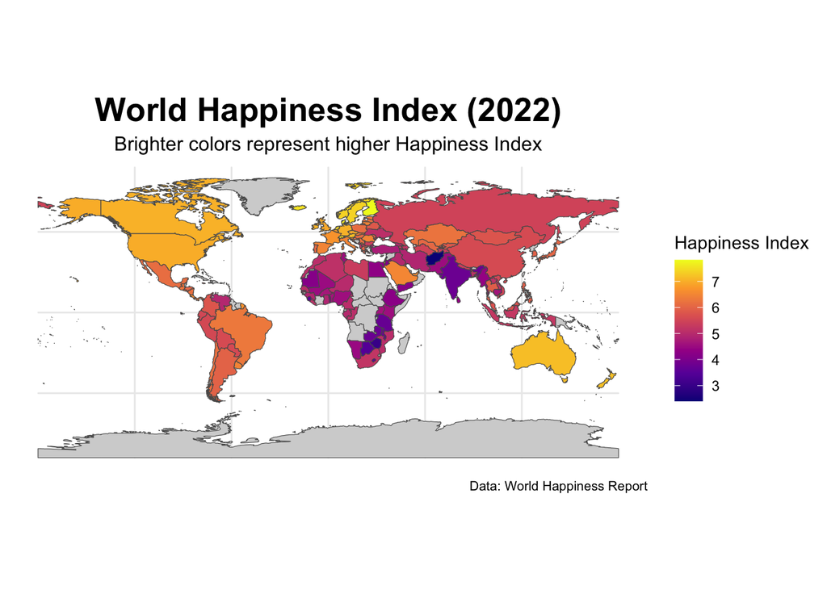

```r
merged_data <- read.csv("data/Happiness_CO2_2022_.csv")

# Get world map data
world <- ne_countries(scale = "medium", returnclass = "sf")

# Merge world map data with happiness data by country
world_happiness <- world %>%
  left_join(merged_data, by = c("name" = "Country"))


# Create the plot
ggplot(data = world_happiness) +
  geom_sf(aes(fill = `Happiness.score`)) +  # Use the Happiness Score for fill
  scale_fill_viridis_c(option = "plasma", na.value = "lightgray", name = "Happiness Index") +
  theme_minimal() +
  labs(title = "World Happiness Index (2022)",
       subtitle = "Brighter colors represent higher Happiness Index",
       caption = "Data: World Happiness Report") +
  theme(
    plot.title = element_text(hjust = 0.5, size = 20, face = "bold"),
    plot.subtitle = element_text(hjust = 0.5, size = 12),
    plot.caption = element_text(size = 8),
    legend.position = "right"
  )
```

## Plotting Happiness Score against CO2 emissions per capita

The scatter plot below shows the relationship between the two parameters

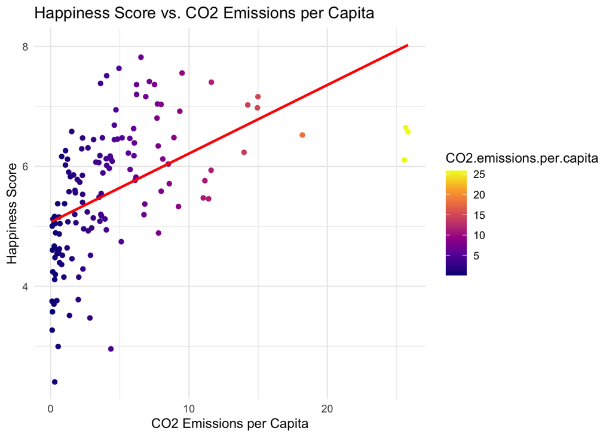

```r
ggplot(merged_data, aes(x = `CO2.emissions.per.capita`, y = `Happiness.score`)) +
  geom_point(aes(color = `CO2.emissions.per.capita`)) +
  scale_color_viridis_c(option = "plasma") +  # Apply Viridis color palette
  geom_smooth(method = "lm", se = FALSE, color = "red") +  # Linear regression line
  theme_minimal() +
  labs(title = "Happiness Score vs. CO2 Emissions per Capita",
       x = "CO2 Emissions per Capita",
       y = "Happiness Score")
```

At first glance, there appears to be a slight positive correlation between CO2 emission per capita and Happiness Score. We take a closer look by splitting the data by continents with the most data points.

```r
library(countrycode)

merged_data$Continent <- countrycode(sourcevar = merged_data$Country,
                                     origin = "country.name",
                                     destination = "continent")
```

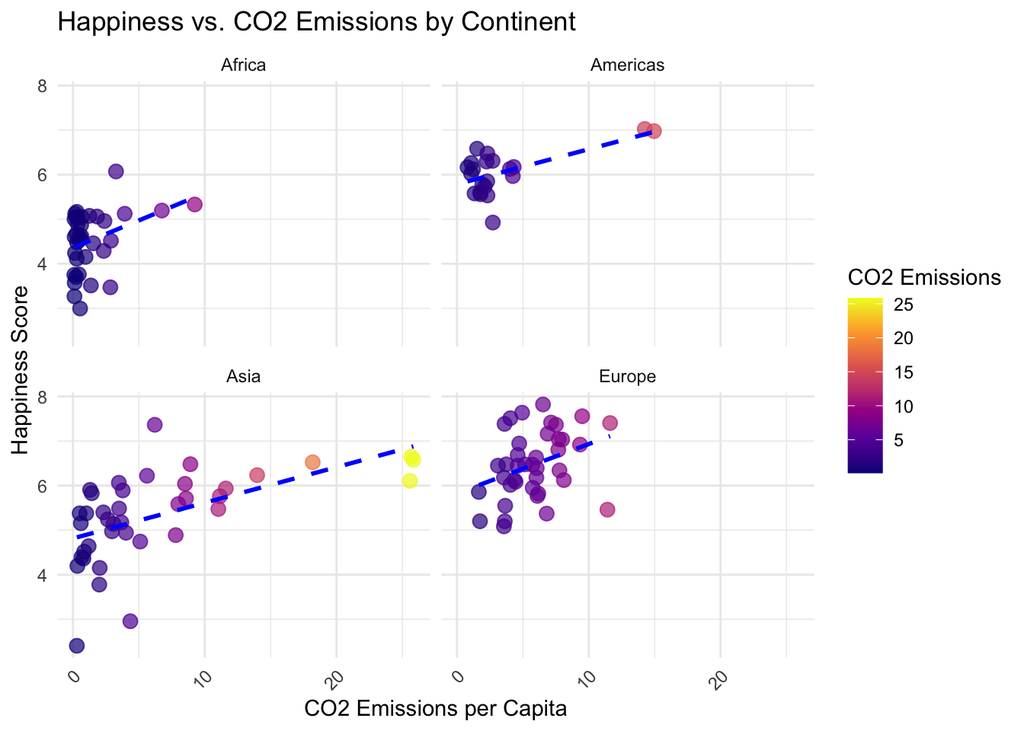

```r
# Filter for specific continents: Americas, Asia, Europe, and Africa
filtered_data <- merged_data %>%
  filter(Continent %in% c("Americas", "Asia", "Europe", "Africa"))

# Create scatter plot with slope line
ggplot(filtered_data, aes(x = `CO2.emissions.per.capita`, y = `Happiness.score`)) +
  geom_point(aes(color = `CO2.emissions.per.capita`), size = 3, alpha = 0.7) +  # Scatter plot points
  scale_color_viridis_c(option = "plasma") +  # Apply Viridis palette for color
  geom_smooth(method = "lm", se = FALSE, color = "blue", linetype = "dashed") +  # Add regression line
  facet_wrap(~Continent) +  # Create facets for each continent
  theme_minimal() +
  labs(title = "Happiness vs. CO2 Emissions by Continent",
       x = "CO2 Emissions per Capita",
       y = "Happiness Score",
       color = "CO2 Emissions") +
  theme(axis.text.x = element_text(angle = 45, hjust = 1))  # Adjust x-axis text for readability
```

We still observe a slight positive correlation across Africa, Amercias, Asia as well as Europe.

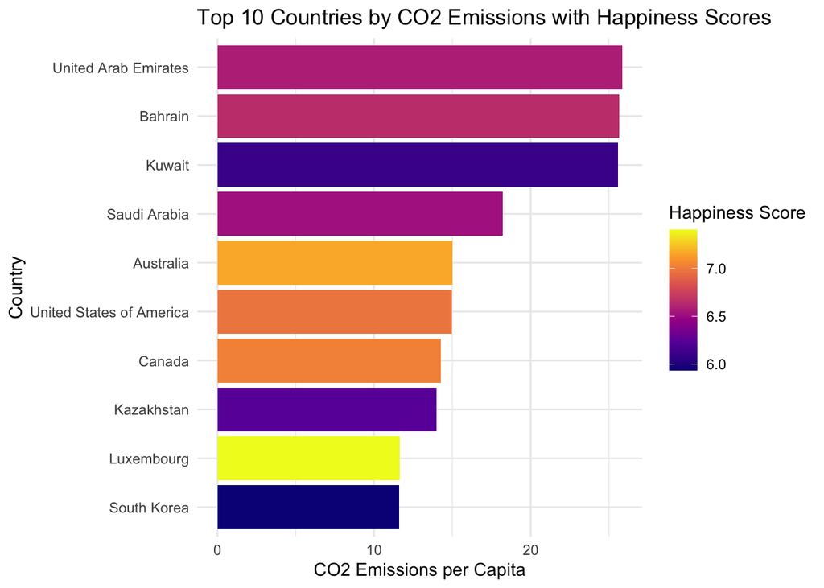

```r
# Top 10 countries by CO2 emissions
top10_co2 <- merged_data %>%
  arrange(desc(`CO2.emissions.per.capita`)) %>%
  slice(1:10)

# Plot for Top 10 countries by CO2 emissions and Happiness Score
top10_plot <- ggplot(top10_co2, aes(x = reorder(Country, `CO2.emissions.per.capita`), y = `CO2.emissions.per.capita`)) +
  geom_col(aes(fill = `Happiness.score`)) +
  scale_fill_viridis_c(option = "plasma") +  # Apply Viridis palette for colors
  coord_flip() +
  theme_minimal() +
  labs(title = "Top 10 Countries by CO2 Emissions with Happiness Scores",
       x = "Country",
       y = "CO2 Emissions per Capita",
       fill = "Happiness Score")

# Bottom 10 countries by least CO2 emissions (ascending order)
bottom10_co2 <- merged_data %>%
  arrange(`CO2.emissions.per.capita`) %>%  # Arrange in ascending order to get countries with least emissions
  filter(`CO2.emissions.per.capita` > 0) %>%  # Exclude countries with zero CO2 emissions if any
  slice(1:10)

# Plot for Bottom 10 countries by least CO2 emissions and Happiness Score
bottom10_plot <- ggplot(bottom10_co2, aes(x = reorder(Country, -`CO2.emissions.per.capita`), y = `CO2.emissions.per.capita`)) +
  geom_col(aes(fill = `Happiness.score`)) +
  scale_fill_viridis_c(option = "plasma") +  # Apply Viridis palette for colors
  coord_flip() +
  theme_minimal() +
  labs(title = "Top 10 Countries by least CO2 Emissions with Happiness Scores",
       x = "Country",
       y = "CO2 Emissions per Capita",
       fill = "Happiness Score")

# Display both plots
print(top10_plot)
```

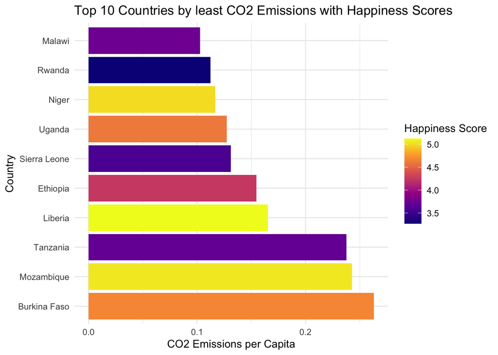

```r
print(bottom10_plot)
```

We now dive a step deeper to take a look at the top 10 and the bottom 10 countries in the world in terms of CO2 emissions per capita along with their happiness score to see if there is a clear pattern. As we can see, there is a lot of variance in the happiness scores of these countries and there is no clear pattern that indicates a strong correlation of a country’s happiness score to its CO2 emissions per capita.

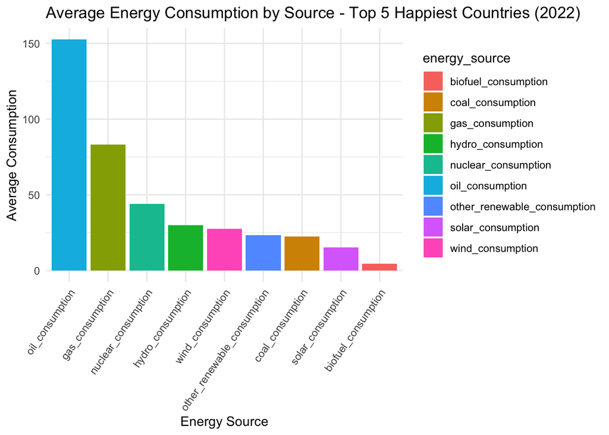

```r
# Load necessary libraries
library(tidyr)

# Read the datasets
energy_data <- read.csv("data/owid energy data.csv")
happiness_data <- read.csv("data/Happiness_CO2_2022_.csv")

# Step 1: Filter happiness data for top 5 happiest countries in 2022
top_5_happiest <- happiness_data %>% arrange(desc(Happiness.score)) %>% head(5)

# Step 2: Extract energy data for the year 2022 and filter for the top happiest countries
energy_data_2022 <- energy_data %>% filter(year == 2022)
top_5_energy_2022 <- energy_data_2022 %>% filter(country %in% top_5_happiest$Country)

# Step 3: Select only columns that have 'consumption' in their names, excluding 'primary_energy_consumption' and 'low_carbon_consumption'
consumption_columns <- grep("consumption", names(energy_data), value = TRUE)
consumption_columns <- setdiff(consumption_columns, c("primary_energy_consumption", "low_carbon_consumption", "fossil_fuel_consumption", "renewables_consumption"))

# Step 4: Calculate average energy consumption for top 5 happiest countries
top_5_average_energy <- top_5_energy_2022 %>%
  select(country, all_of(consumption_columns)) %>%
  pivot_longer(cols = -country, names_to = "energy_source", values_to = "consumption") %>%
  filter(!is.na(consumption) & consumption > 0) %>%  # Exclude NA and zero consumption values
  group_by(energy_source) %>%
  summarise(average_consumption = mean(consumption, na.rm = TRUE)) %>%
  arrange(desc(average_consumption))

# Step 5: Create bar plot for average energy consumption of each energy source for the top 5 happiest countries
top_5_plot <- ggplot(top_5_average_energy, aes(x = reorder(energy_source, -average_consumption), y = average_consumption, fill = energy_source)) +
  geom_bar(stat = "identity") +
  labs(title = "Average Energy Consumption by Source - Top 5 Happiest Countries (2022)", x = "Energy Source", y = "Average Consumption") +
  theme_minimal() +
  theme(axis.text.x = element_text(angle = 55, hjust = 1))

# Display the plot
print(top_5_plot)
```

The final step is to look at the energy source mix for the top 5 happiest countries. Clearly, oil and gas lead by a significant margin against renewable sources of energy for these countries.

This, in part, goes against our null hypothesis where the assumption was the happiest countries would likely largely use renewable sources of energy.

In conclusion, there isn’t a strong correlation between the happiness index of a country and it’s CO2 emissions per capita which indicates that a country with low emissions isn’t certainly likely to also be happy.